# AML Outcome Summary

# 1 Definition

- **Consolidation or maintenance**:
  - 1 : when rx_indication in [3 (Consolidation of CR), 4(Maintenance of CR), 8 (Consolidation f/b “maintenance” (no restaging between))];
  - 0 otherwise.
- **decision points**: if it is a treatment, but not a Hydroxyurea (e_treatment___3).
- **Days between decision points**: days between two adjcent decision points
- **Days between decision point and relapse**: days between the relapse and the last decision points, e.g., date at relapse - date at last decision point

# 2 Understand patient population

## 2.1 Total patient

```
##   No. of unique patient
## 1                   344
```

## 2.2 Alive or Dead

```
## .
## Alive  Dead
##    38   306
```

## 2.3 How many patients never get treatments?

We have 287 patients have treatment history and has relapse.

```
##                is_relapse
## is_treatment    Has Relapse No Relapse
##   Has treatment         287          1
##   No treatment           55          1
```

```
##                is_CR
## is_treatment    Complete Remission (CR) No CR
##   Has treatment                     128   160
##   No treatment                        9    47
```

## 2.4 Number of treatments OR decision points patients received

**1. No. of total treatments**

This section shows the number of total treatments one patient could receive. Note: patient counts per each number of treatment, e.g., 56 patients has 0 treatments.

Table. Total number of treatment a patient received thrughout his/her records.

```
##
##   0   1   2   3   4   5   6   7   8   9  10  11  12  13  14  17  20  22
##  56 102  51  41  28  19   7  10   5   4   4   4   2   4   3   2   1   1
```

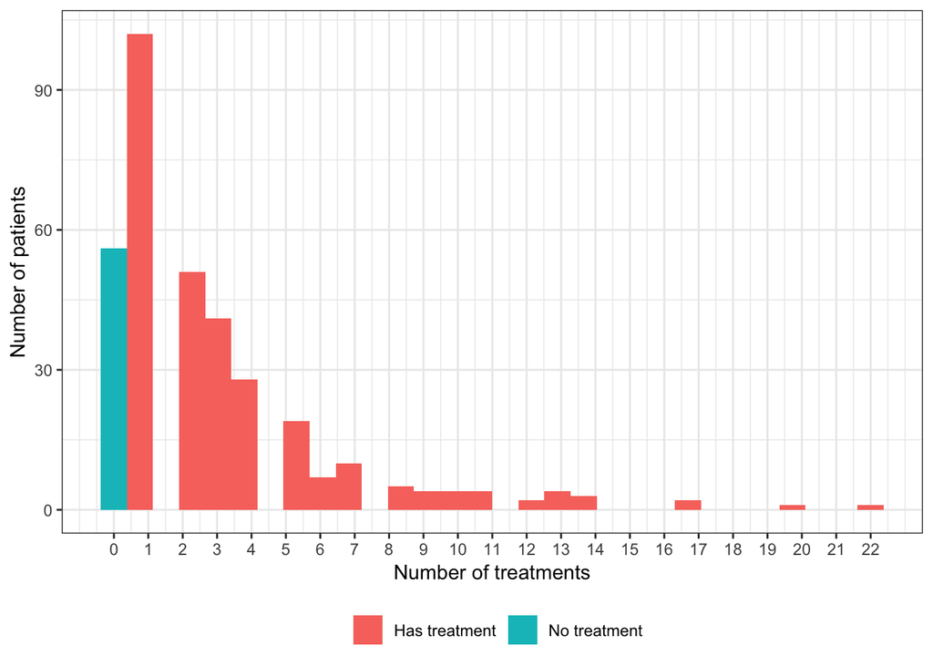

Figure 2.1: Number of treatments

**2. No. of decisions**

Patient counts per each number of decision points, e.g., 58 patients has 0 decision points.

```
##
##   0   1   2   3   4   5   6   7   8   9  10  11  13
##  58 140  54  40  17  12   3   7   7   1   2   2   1
```

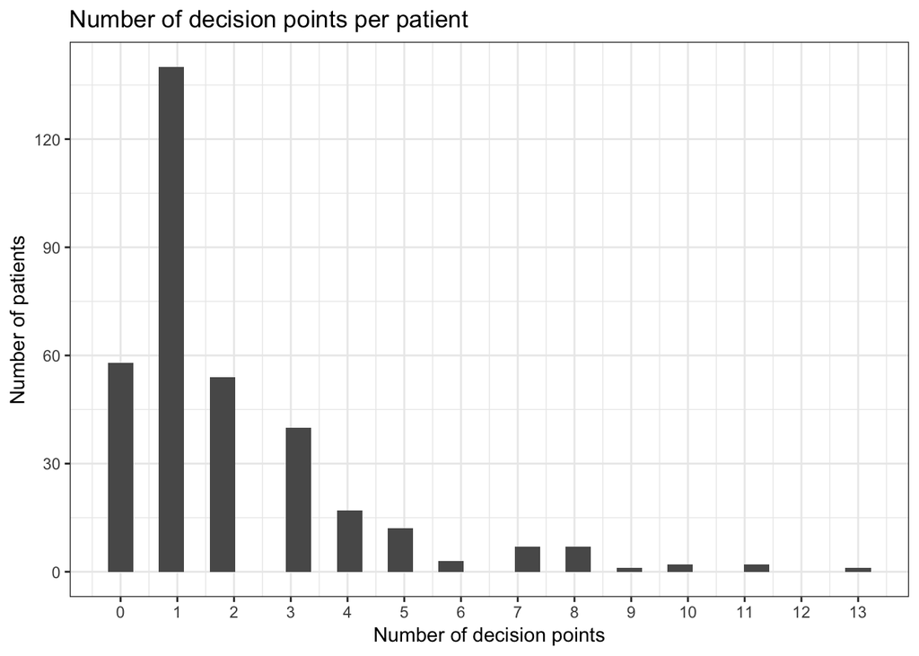

Figure 2.2: Number of decision points per patient

## 2.5 Duration between decision points

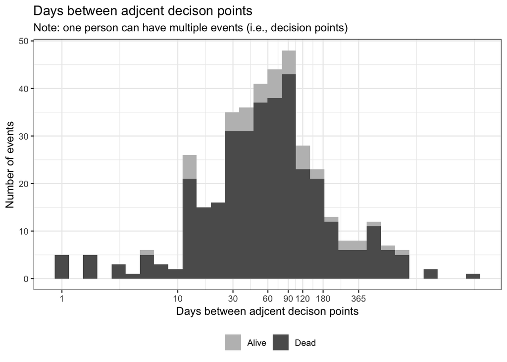

Figure 2.3: Days between adjcent decison points

There are 18 patients have at least two decision points within 10 days. Table below shows the list of these patients. Should we consider them as two decision points if they are only few days apart?

|  | subject_id | redcap_repeat_instrument | event_date | event_type | decision_point | decision_duration |
| --- | --- | --- | --- | --- | --- | --- |
| 1 | 0277965 | response_or_relapse_event | 2014-01-22 | Relapse | 0 |  |
| 2 | 0277965 | treatment_event | 2014-02-01 | e_treatment___1 | 1 |  |
| 3 | 0277965 | response_or_relapse_event | 2014-04-09 | Relapse | 0 |  |
| 4 | 0277965 | treatment_event | 2014-04-16 | e_treatment___1 | 1 |  |
| 5 | 0277965 | response_or_relapse_event | 2014-05-09 | Relapse | 0 |  |
| 6 | 0277965 | treatment_event | 2014-06-04 | e_treatment___8 | 1 |  |
| 7 | 0277965 | treatment_event | 2014-06-11 | e_treatment___6 | 1 | 7 |
| 8 | 0277965 | Dead | 2014-07-29 | Dead | 0 |  |
| 9 | 2650036 | response_or_relapse_event | 2008-11-14 | Relapse | 0 |  |
| 10 | 2650036 | treatment_event | 2008-12-01 | e_treatment___6 | 1 |  |

[output cut: 247 more lines]

## 2.6 Duration between decision points and relapse

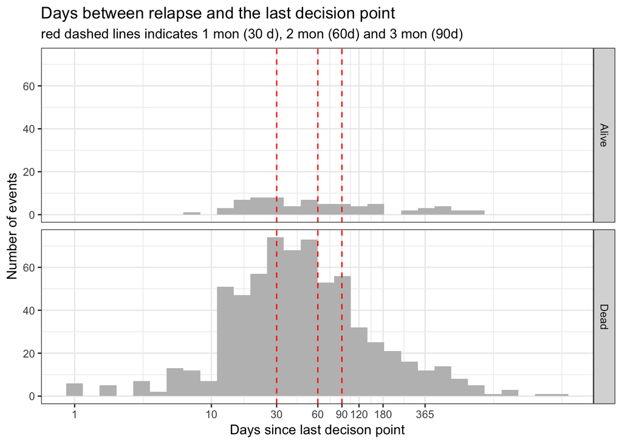

Figure 2.4: Days between relapse and the last decision point

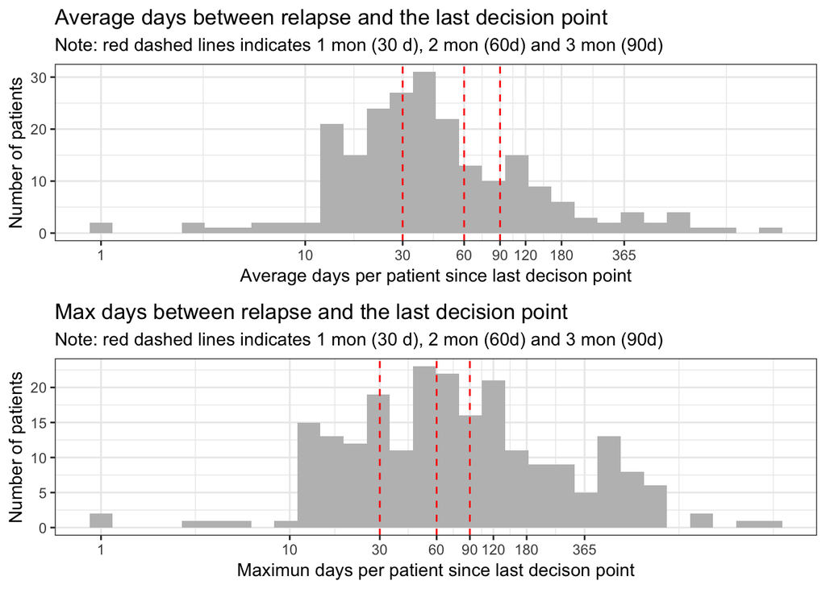

Figure 2.5: Average days between relapse and the last decision point

# 3 Data snippets

## 3.1 Event data ()

|  | subject_id | redcap_repeat_instrument | event_date | event_type | n_tx | maintenance_consolidation | decision_point |
| --- | --- | --- | --- | --- | --- | --- | --- |
| 1 | 2236847 | response_or_relapse_event | 2003-01-29 | Relapse |  |  | 0 |
| 2 | 2236847 | response_or_relapse_event | 2003-03-10 | Relapse |  |  | 0 |
| 3 | 2236847 | treatment_event | 2003-03-26 | e_treatment___1 | 1 | 0 | 1 |
| 4 | 2236847 | response_or_relapse_event | 2003-04-28 | CR |  |  | 0 |
| 5 | 2236847 | treatment_event | 2003-05-08 | e_treatment___10 | 2 | 1 | 0 |
| 6 | 2236847 | response_or_relapse_event | 2003-06-10 | CR |  |  | 0 |
| 7 | 2236847 | response_or_relapse_event | 2003-09-09 | CR |  |  | 0 |
| 8 | 2236847 | response_or_relapse_event | 2004-01-05 | CR |  |  | 0 |
| 9 | 2236847 | response_or_relapse_event | 2004-05-24 | CR |  |  | 0 |
| 10 | 2236847 | response_or_relapse_event | 2004-12-27 | CR |  |  | 0 |

[output cut: 22 more lines]

## 3.2 Duration between decision points and following relapse

|  | subject_id | redcap_repeat_instrument | event_date | event_type | n_tx | first_treatment | days_since_last_decision_point | days_since_initial_decision_point |
| --- | --- | --- | --- | --- | --- | --- | --- | --- |
| 1 | 2236847 | treatment_event | 2003-03-26 | e_treatment___1 | 1 | 2003-03-26 | 0 | 0 |
| 2 | 2236847 | response_or_relapse_event | 2007-03-29 | Relapse |  | 2003-03-26 | 1454 | 4063 |
| 3 | 2236847 | response_or_relapse_event | 2007-04-03 | Relapse |  | 2003-03-26 | 1459 | 5522 |
| 4 | 2236847 | treatment_event | 2007-04-05 | e_treatment___1 | 2 | 2003-03-26 | 0 | 0 |
| 5 | 2236847 | treatment_event | 2007-05-21 | e_treatment___2 | 1 | 2003-03-26 | 0 | 0 |
| 6 | 2236847 | response_or_relapse_event | 2008-07-25 | Relapse |  | 2003-03-26 | 378 | 1158 |
| 7 | 2236847 | treatment_event | 2008-08-04 | e_treatment___1 | 1 | 2003-03-26 | 0 | 0 |
| 8 | 2236847 | response_or_relapse_event | 2009-02-12 | Relapse |  | 2003-03-26 | 183 | 318 |
| 9 | 2236847 | response_or_relapse_event | 2009-05-21 | Relapse |  | 2003-03-26 | 281 | 599 |